# Lesson 0: Configuring your computer

(c) 2017 Justin Bois. This work is licensed under a [Creative Commons Attribution License CC-BY 4.0](https://creativecommons.org/licenses/by/4.0/). All code contained herein is licensed under an [MIT license](https://opensource.org/licenses/MIT).

*This tutorial was generated from a Jupyter notebook. You can download the notebook here.*

In this lesson, you will set up a Python computing environment for scientific computing. There are two main ways people set up Python for scientific computing.

1. By downloading and installing package by package with tools like [apt-get](https://help.ubuntu.com/community/AptGet/Howto), [pip](https://docs.python.org/3/installing/), etc.
2. By downloading and installing a Python distribution that contains binaries of many of the scientific packages needed. The major distributions of these are [Anaconda](https://store.continuum.io/cshop/anaconda/) and [Enthought Canopy](https://www.enthought.com/products/canopy/). Both contain IDEs.

In this class, we will use Anaconda, with its associated package manager, `conda`. It has recently become the de facto package manager/distribution for scientific use.

Before you do that, though, you might as well....

## Set up an account on GitHub

We will use Git/GitHub extensively in the bootcamp. Go to http://github.com/ to get an account. You should register with your Caltech address so you get free private repositories as academics. You should also think carefully about picking your username. There is a good chance other people in your professional life will see this.

## Python 2 vs Python 3

We are at an interesting point in Python's history. Python is currently in version 3.6 (as of June 1, 2017). The problem is that Python 3.x is not backwards compatible with Python 2.x. Many scientific packages were written in Python 2.x and have been very slow to update to Python 3. However, Python 3 is Python's present and future, so all packages eventually need to work in Python 3. Today, most important scientific packages work in Python 3 (and some now *only* in Python 3). All of the packages we will use do, so we will use Python 3 in this course.

For those of you who are already using Anaconda with Python 2, you can [create a Python 3 environment](http://conda.pydata.org/docs/py2or3.html#create-python-2-or-3-environments).

## Downloading and installing Anaconda

Downloading and installing Anaconda is simple.

1. Go to the [Anaconda homepage](https://store.continuum.io/cshop/anaconda/) and download the graphical installer.
2. Be sure to download Anaconda for Python 3.6.
3. Follow the on-screen instructions for installation.

That's it! After you do that, you will have a functioning Python distribution.

## Accessing the command line

**Note**: Do the steps below only *after* you have finished the installation of Anaconda.

During the bootcamp, you will need to access the command line. Doing this on a Mac or Linux is simple. If you are using Linux, it's a good bet you already know how to navigate a terminal, so we will not give specific instructions for Linux. For a Mac, you can fire up the Terminal application. It is typically in the `/Applications/Utilities` folder. Otherwise, hold down Command `⌘`-space bar and type "terminal" in the search box, and select the Terminal Application.

For Windows, download and install [Git Bash](https://git-for-windows.github.io). After you have installed it, simply right click anywhere on your Desktop, and you should have an option to run Git Bash. You will then have a prompt that looks very much like Mac and Linux users will have.

## The conda package manager

conda is a package manager for keeping all of your packages up-to-date. It has plenty of functionality beyond our basic usage in class, which you can learn more about by reading the [docs](http://conda.pydata.org/docs/get-started.html). We will primarily be using conda to install and update packages.

conda works from the command line. Now that you know how to get a command line prompt, you can start using conda. The first thing we'll do is update conda itself. To do this, enter the following on the command line:

```
conda update conda
```

If conda is out of date and needs to be updated, you will be prompted to perform the update. Just type `y`, and the update will proceed.

Now that conda is updated, we'll use it to see what packages are installed. Type the following on the command line:

```
conda list
```

This gives a list of all packages and their versions that are installed. Now, we'll update all packages, so type the following on the command line:

```
conda update --all
```

If anything is out of date, you will be prompted to perform the updates. (If everything is up to date, you will just see a list of all the installed packages.) They may even be some downgrades. This happens when there are package conflicts where one package requires an earlier version of another. conda is very smart and figures all of this out for you, so you can almost always say "yes" (or "`y`") to conda when it prompts you.

## The Atom text editor

Since we will be writing code, we need a text editor to do so. There are countless options. For example, Anaconda comes with an **interactive developer environment** (IDE) called [Spyder](https://pythonhosted.org/spyder/), which is built for scientific computing. [Sublime Text](https://www.sublimetext.com) is a widely used text editor. For this class, we will use [Atom](https://atom.io), which is currently my own text editor of choice.

To download and install Atom, go to [its website](https://atom.io) and follow the instructions. Once it's installed, you have a good text editor to use in the bootcamp and beyond.

The default configuration of Atom will work well for you, but you have to be careful with how tabs are defined. In the Atom menu, go to

```
Packages -> Settings View -> Open
```

This will open the Settings page for Atom. Scroll toward the bottom of that page, and make sure `Tab Length` is set to 4. Underneath that, make sure `Tab Type` is set to `soft`. As you will soon learn, this is important in Python because indentation matters.

## IPython

In the bootcamp, we will be using an IPython shell. IPython is a package that allows for easier interaction with the Python interpreter than the standard interactive Python does. To fire up an IPython shell, just enter

```
ipython
```

at the command line. This will give you an interactive IPython shell that we will make great use of, particularly during the beginning of the bootcamp.

## Checking your distribution

We'll now run a quick test to make sure things are working properly. We will make a quick plot that requires several of the scientific libraries we will use in the bootcamp.

Open an new file in Atom using

```
File -> New
```

With the exception of the obvious omission, paste the code below into the text editor and save it as `welcome_bootcamp.py`. Make sure you save it in your home directory.

After you do that, type

```
run welcome_bootcamp.py
```

at the prompt in the IPython shell. You will get a graphic that looks like the one below. In Windows, you may have to click an icon on the bottom tool bar to view it. If you get this plot, excellent! You now have a functioning Python environment for scientific computing!

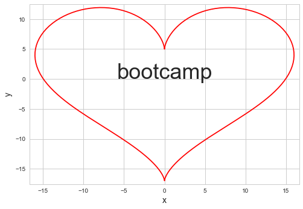

```python
# Do not enter the next line. This is only to prepare this tutorial.
%matplotlib inline

# Paste everything following
import numpy as np
import matplotlib.pyplot as plt
import seaborn as sns
sns.set(style='whitegrid')

# Generate plotting values
t = np.linspace(0, 2*np.pi, 200)
x = 16 * np.sin(t)**3
y = 13 * np.cos(t) - 5 * np.cos(2*t) - 2 * np.cos(3*t) - np.cos(4*t)

# Generate the plot
plt.plot(x, y, 'r-')
plt.text(0, 0, 'bootcamp', fontsize=36, ha='center')
plt.margins(0.02)
plt.xlabel('x', fontsize=14)
plt.ylabel('y', fontsize=14)
plt.draw()
plt.show()
```